# VKOR_abundance_activity_analysis_pipeline

Melissa Chiasson

5/8/2020

# Analysis setup

This R markdown file will go through the processes of analyzing the data for the manuscript, “Multiplexed measurement of variant abundance and activity reveals VKOR topology, active site and human variant impact,” using the supplemental data file containing variant abundance and activity scores as the starting point. These files are provided as supplementary data files from the journal, and can also be obtained at our GitHub repo. Please place these files in the same directory as this R Markdown file to allow the analyses to proceed.

Furthermore, create a directory titled “Output” in the same directory as this R Markdown file to create the graphics files used to generate the figures.

## Initial setup (load packages, create default theme)

## Install and/or load required packages

```r
if(!require(ggplot2)){install.packages("ggplot2")}
library(ggplot2)

if(!require(ggdendro)){install.packages("ggdendro")}
library(ggdendro)

if(!require(plyr)){install.packages("plyr")}
library(plyr)

if(!require(dplyr)){install.packages("dplyr")}
library(dplyr)

if(!require(tidyr)){install.packages("tidyr")}
library(tidyr)

if(!require(reshape)){install.packages("reshape")}
library(reshape)

if(!require(data.table)){install.packages("data.table")}
library(data.table)

if(!require(scales)){install.packages("scales")}
library(scales)

if(!require(GGally)){install.packages("GGally")}
library(GGally)

if(!require(grid)){install.packages("grid")}
library(grid)

if(!require(MASS)){install.packages("MASS")}
library(MASS)

if(!require(mixtools)){install.packages("mixtools")}
```

```
## mixtools package, version 1.1.0, Released 2017-03-10
## This package is based upon work supported by the National Science Foundation under Grant No. SES-0518772.
```

```r
library(mixtools)

if(!require(zoo)){install.packages("zoo")}
library(zoo)

if(!require(ggrepel)){install.packages("ggrepel")}
library(ggrepel)

if(!require(dendextend)){install.packages("dendextend")}
```

[output not shown]

```r
library(dendextend)

if(!require(devtools)){install.packages("devtools")}
library(devtools)

if(!require(VennDiagram)){install.packages("VennDiagram")}
```

```r
library(VennDiagram)

## The package versions used by the author
packageVersion("ggplot2") #‘3.2.1’
```

```
## [1] '3.2.1'
```

```r
packageVersion("plyr") #‘1.8.4’
```

```
## [1] '1.8.4'
```

```r
packageVersion("dplyr") #‘0.8.1’
```

```
## [1] '0.8.5'
```

```r
packageVersion("reshape") #‘0.8.8’
```

```
## [1] '0.8.8'
```

```r
packageVersion("data.table") #‘1.12.2’
```

```
## [1] '1.12.2'
```

```r
packageVersion("scales") #‘1.1.0’
```

```
## [1] '1.1.0'
```

```r
packageVersion("GGally") #‘1.4.0’
```

```
## [1] '1.4.0'
```

```r
packageVersion("ggdendro") #‘0.1.20’
```

```
## [1] '0.1.20'
```

```r
packageVersion("grid") #‘3.5.2’
```

```
## [1] '3.5.2'
```

```r
packageVersion("MASS") #‘7.3.51.4’
```

```
## [1] '7.3.51.4'
```

```r
packageVersion("mixtools") #‘1.1.0’'
```

```
## [1] '1.1.0'
```

```r
packageVersion("zoo") #‘1.8.6’
```

```
## [1] '1.8.6'
```

```r
packageVersion("ggrepel") #‘0.8.1’
```

```
## [1] '0.8.1'
```

```r
packageVersion("dendextend") #‘1.12.0’
```

```
## [1] '1.12.0'
```

```r
packageVersion("devtools") #‘2.2.1’
```

```
## [1] '2.2.1'
```

```r
packageVersion("VennDiagram") #‘1.6.20’
```

```
## [1] '1.6.20'
```

Create custom functions

```r
to_single_notation <- function(arg1){
if(toupper(arg1) == "ALA"){return("A")}
if(toupper(arg1) == "CYS"){return("C")}
if(toupper(arg1) == "ASP"){return("D")}
if(toupper(arg1) == "GLU"){return("E")}
if(toupper(arg1) == "PHE"){return("F")}
if(toupper(arg1) == "GLY"){return("G")}
if(toupper(arg1) == "HIS"){return("H")}
if(toupper(arg1) == "ILE"){return("I")}
if(toupper(arg1) == "LYS"){return("K")}
if(toupper(arg1) == "LEU"){return("L")}
if(toupper(arg1) == "MET"){return("M")}
if(toupper(arg1) == "ASN"){return("N")}
if(toupper(arg1) == "PRO"){return("P")}
if(toupper(arg1) == "GLN"){return("Q")}
if(toupper(arg1) == "ARG"){return("R")}
if(toupper(arg1) == "SER"){return("S")}
if(toupper(arg1) == "THR"){return("T")}
if(toupper(arg1) == "VAL"){return("V")}
if(toupper(arg1) == "TRP"){return("W")}
if(toupper(arg1) == "TYR"){return("Y")}
if(toupper(arg1) == "TER"){return("X")}
}

amino_acid_class <- function(input_frame){
if(input_frame[x,"end"] %in% c("D","E")){input_frame[x,"end_class"] <- "Acidic"}
if(input_frame[x,"end"] %in% c("H","K","R")){input_frame[x,"end_class"] <- "Basic"}
if(input_frame[x,"end"] %in% c("S","T","N","Q")){input_frame[x,"end_class"] <- "Hydrophilic uncharged"}
if(input_frame[x,"end"] %in% c("G","A","V","I","L")){input_frame[x,"end_class"] <- "Aliphatic uncharged"}
if(input_frame[x,"end"] %in% c("C","M","P")){input_frame[x,"end_class"] <- "Nonpolar uncharged"}
if(input_frame[x,"end"] %in% c("F","Y","W")){input_frame[x,"end_class"] <- "Aromatic"}
}

to_max_asa <- function(arg1){
if(toupper(arg1) == "A"){return(113)}
if(toupper(arg1) == "C"){return(140)}
if(toupper(arg1) == "D"){return(151)}
if(toupper(arg1) == "E"){return(183)}
if(toupper(arg1) == "F"){return(218)}
if(toupper(arg1) == "G"){return(85)}
if(toupper(arg1) == "H"){return(194)}
if(toupper(arg1) == "I"){return(182)}
if(toupper(arg1) == "K"){return(211)}
if(toupper(arg1) == "L"){return(180)}
if(toupper(arg1) == "M"){return(204)}
if(toupper(arg1) == "N"){return(158)}
if(toupper(arg1) == "P"){return(143)}
if(toupper(arg1) == "Q"){return(189)}
if(toupper(arg1) == "R"){return(241)}
if(toupper(arg1) == "S"){return(122)}
if(toupper(arg1) == "T"){return(146)}
if(toupper(arg1) == "V"){return(160)}
if(toupper(arg1) == "W"){return(259)}
if(toupper(arg1) == "Y"){return(229)}
}
```

# Create universal changes to the baseline ggplot2 theme

```r
theme_new <- theme_set(theme_classic())
```

```r
vkor_variants<-read.csv("vkor_abundance_activity_scores_variants.csv",header=TRUE)
vkor_positions<-read.csv("vkor_abundance_activity_scores_positions.csv",header=TRUE)
#vkor_variants <- read.csv(file = "*Insert the name of the VKOR variant data file here*", header = TRUE)
#vkor_positions <- read.csv(file = "*Insert the name of the VKOR positional data file here*", header = TRUE)
```

#### Summary data stats of VKOR scores

```r
paste("There are ",nrow(subset(vkor_variants, class == "synonymous" & !is.na(abundance_score))), " synonymous VKOR variants with abundance scores",sep="")
```

```
## [1] "There are 127 synonymous VKOR variants with abundance scores"
```

```r
paste("There are ",nrow(subset(vkor_variants, class == "nonsense" & !is.na(abundance_score))), " nonsense VKOR variants with abundance scores",sep="")
```

```
## [1] "There are 88 nonsense VKOR variants with abundance scores"
```

```r
paste("There are ",nrow(subset(vkor_variants, class == "missense" & !is.na(abundance_score))), " single amino acid VKOR variants with abundance scores",sep="")
```

```
## [1] "There are 2695 single amino acid VKOR variants with abundance scores"
```

```r
paste("There are ",nrow(subset(vkor_variants, class == "missense" & !is.na(abundance_score) & abundance_class == "low")), " single amino acid VKOR variants with low abundance scores",sep="")
```

```
## [1] "There are 908 single amino acid VKOR variants with low abundance scores"
```

```r
paste("There are ",nrow(subset(vkor_variants, !is.na(abundance_score) & abundance_class == "low")), " VKOR variants with low abundance scores",sep="")
```

```
## [1] "There are 981 VKOR variants with low abundance scores"
```

```r
paste("There are ",nrow(subset(vkor_variants, class == "synonymous" & !is.na(activity_score))), " synonymous VKOR variants with activity scores",sep="")
```

```
## [1] "There are 35 synonymous VKOR variants with activity scores"
```

```r
paste("There are ",nrow(subset(vkor_variants, class == "nonsense" & !is.na(activity_score))), " nonsense VKOR variants with activity scores",sep="")
```

```
## [1] "There are 14 nonsense VKOR variants with activity scores"
```

```r
paste("There are ",nrow(subset(vkor_variants, class == "missense" & !is.na(activity_score))), " single amino acid VKOR variants with activity scores",sep="")
```

```
## [1] "There are 697 single amino acid VKOR variants with activity scores"
```

```r
paste("There are ",nrow(subset(vkor_variants, class == "missense" & !is.na(activity_score) & activity_class == "low")), " single amino acid VKOR variants with low activity scores",sep="")
```

```
## [1] "There are 19 single amino acid VKOR variants with low activity scores"
```

```r
paste("There are ",nrow(subset(vkor_variants, !is.na(activity_score) & activity_class == "low")), " VKOR variants with low activity scores",sep="")
```

[output not shown]

## Defining some useful boundaries for analysis and plotting

```r
vkor_synonymous_5th_abundance <- quantile(subset(vkor_variants, class == "synonymous")$abundance_score, 0.05,na.rm = TRUE)
vkor_lower_bound_abundance <- as.numeric(quantile(subset(vkor_variants, class == "missense")$abundance_score, 0.1, na.rm = TRUE))
vkor_upper_bound_abundance <- median(subset(vkor_variants, class == "synonymous")$abundance_score,na.rm = TRUE)

vkor_synonymous_5th_activity <- quantile(subset(vkor_variants, class == "synonymous")$activity_score, 0.05, na.rm = TRUE)
vkor_lower_bound_activity <- as.numeric(quantile(subset(vkor_variants, class == "missense")$activity_score, 0.1, na.rm = TRUE))
vkor_upper_bound_activity <- median(subset(vkor_variants, class == "synonymous")$activity_score, na.rm = TRUE)
```

#### Plots of nonsense variant scores by position

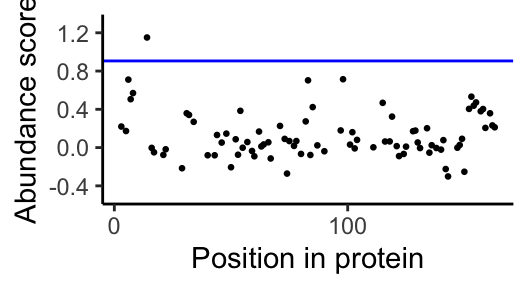

```r
#Abundance score
vkor_trunc_score_position_plot_abundance <- ggplot(data = subset(vkor_variants, class == "nonsense"), aes(x = as.numeric(position), y = abundance_score)) + geom_point(size = 0.5) +
ylab("Abundance score") + xlab("Position in protein") + geom_hline(yintercept = vkor_variants[vkor_variants$class == "wt","abundance_score"], color = "blue") +
scale_y_continuous(limits = c(-0.5,1.3), breaks = c(-0.4,0,0.4,0.8,1.2)) + scale_x_continuous(breaks = c(0,100,200,300,400))
plot(vkor_trunc_score_position_plot_abundance)
```

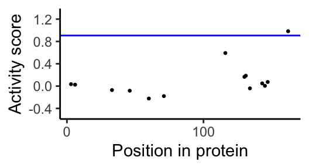

```r
ggsave(file = "Output/vkor_abundance_trunc_score_position_plot.pdf", vkor_trunc_score_position_plot_abundance, height = 1.5, width = 2.25)

#Activity score
vkor_trunc_score_position_plot_activity <- ggplot(data = subset(vkor_variants, class == "nonsense"), aes(x = as.numeric(position), y = activity_score)) + geom_point(size = 0.5) +
ylab("Activity score") + xlab("Position in protein") + geom_hline(yintercept = vkor_variants[vkor_variants$class == "wt","activity_score"], color = "blue") +
scale_y_continuous(limits = c(-0.5,1.3), breaks = c(-0.4,0,0.4,0.8,1.2)) + scale_x_continuous(breaks = c(0,100,200,300,400))
plot(vkor_trunc_score_position_plot_activity)
```

```r
ggsave(file = "Output/vkor_activity_trunc_score_position_plot.pdf", vkor_trunc_score_position_plot_activity, height = 1.5, width = 2.25)
```

#### Figure 1c: Make a VKOR density plot that also serves as the heatmap legend for abundance data

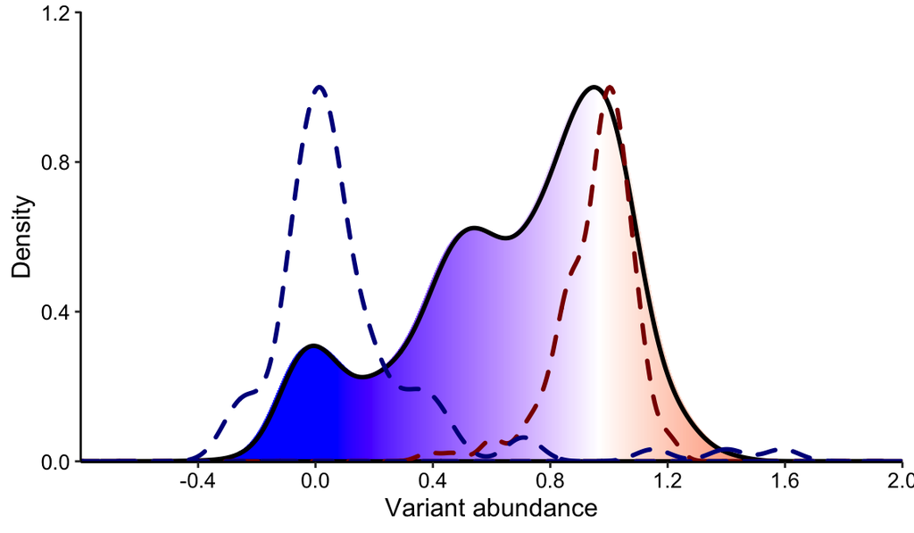

```r
vkor_m <- ggplot(data = subset(vkor_variants, class == "missense"), aes(x = abundance_score, y = ..scaled..))
vkor_m <- vkor_m + geom_density()
vkor_q <- ggplot_build(vkor_m)$data[[1]]
vkor_q_low <- subset(vkor_q, x <= vkor_lower_bound_abundance)
vkor_q_mid <- subset(vkor_q, x > vkor_lower_bound_abundance & x < vkor_upper_bound_abundance)
vkor_q_high <- subset(vkor_q, x >= vkor_upper_bound_abundance)

vkor_heatmap_density_abundance <- ggplot() +
geom_segment(data = vkor_q_low , aes(x = x, y = y, xend = x, yend = 0), colour = "blue", size = 2) +
geom_segment(data = vkor_q_mid, aes(x = x, y = y, xend = x, yend = 0, colour = x), size = 2) +
geom_segment(data = vkor_q_high, aes(x = x, y = y, xend = x, yend = 0, colour = x), size = 2) +
geom_density(data = subset(vkor_variants, class == "missense"), aes(x = abundance_score, y = ..scaled..), size = 1) +
scale_color_gradientn(colours = c("blue","white","red"), values = rescale(c(vkor_lower_bound_abundance,vkor_upper_bound_abundance,2)), limits=c(vkor_lower_bound_abundance,2)) +
scale_x_continuous(limits = c(-0.8, 2), breaks = seq(-0.4,2,0.4), expand = c(0,0)) +
scale_y_continuous(limits = c(0,1.2), breaks = c(0,0.4,0.8,1.2), expand = c(0,0.002)) + xlab("Variant abundance") + ylab("Density") +
theme_classic()+theme(axis.text.x =element_text(size=10,color="black"),
        axis.text.y=element_text(size=10,color="black"),
        axis.title=element_text(size=12,color="black"),
        panel.background = element_rect(fill = "white"),
        legend.position = "none",
        axis.line = element_line(colour = "black")) +
geom_density(data = subset(vkor_variants, class == "synonymous"), aes(x = abundance_score, y = ..scaled..), color = "darkred", alpha = 0.4, size = 1, linetype = 2) +
geom_density(data = subset(vkor_variants, class == "nonsense" & position > 10 & position < 153), aes(x = abundance_score, y = ..scaled..), color = "darkblue", alpha = 0.4, size = 1, linetype = 2)
plot(vkor_heatmap_density_abundance)
```

```r
ggsave(file = "Output/vkor_heatmap_density_abundance.pdf", vkor_heatmap_density_abundance, height = 2, width = 4)
```

[figure not shown]

#### Figure 1e: Graph number of variants we see at each position in abundance and activity data

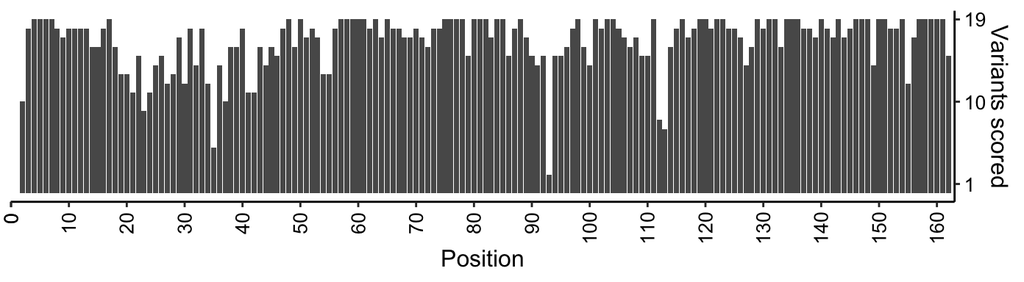

```r
vkor_variants_scored_plot_abundance<-ggplot(vkor_positions,aes(x=position,y=variants_scored_abundance))+geom_bar(stat="identity")+ scale_x_continuous(expand = c(0,0.05), lim=c(0,163),breaks = c(0, seq(0,163,10)))+scale_y_continuous(breaks = c(1,10,19),position="right") + xlab("Position") + ylab("Variants scored") +theme_classic()+theme(axis.text.x=element_text(size=10,color="black",angle = 90,hjust=0.95,vjust=0.5),axis.text.y=element_text(size=10,color="black"),axis.title.x=element_text(size=12),axis.title.y=element_text(size=12))
plot(vkor_variants_scored_plot_abundance)
```

```r
ggsave(file = "Output/vkor_positions_variants_scored_graph_abundance.pdf", vkor_variants_scored_plot_abundance, height = 1, width = 5.35)
```

```r
clonal_validation_data<-read.csv("VAMP-Seq_validation_clones_flow_data.csv",header=TRUE)

cor(clonal_validation_data$score,clonal_validation_data$mean_ratio,method="pearson")
```

```
## [1] 0.9640687
```

```r
cor(clonal_validation_data$score,clonal_validation_data$mean_ratio,method="spearman")
```

```
## [1] 0.9727273
```

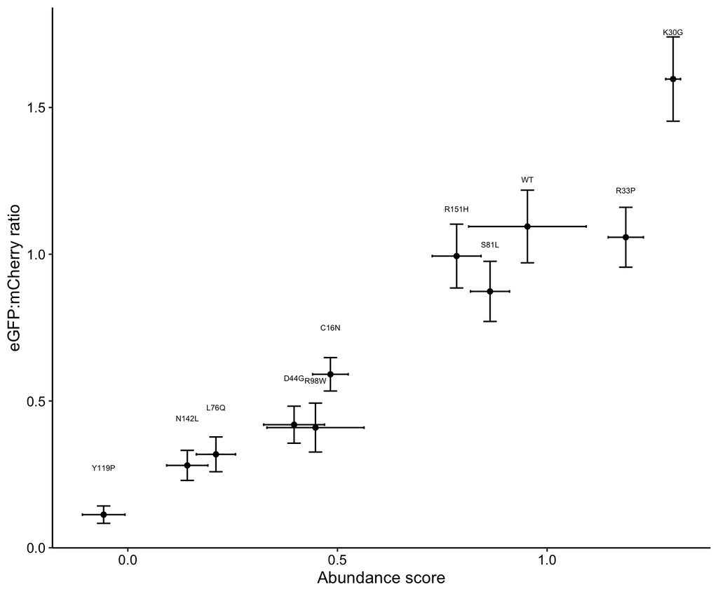

```r
clonal_validation_plot<-ggplot(clonal_validation_data,aes(x=score,y=mean_ratio))+geom_point()+geom_errorbar(aes(ymin=mean_ratio-se,ymax=mean_ratio+se))+geom_errorbarh(aes(xmin=score-score_se, xmax=score+score_se))+annotate("text", x = clonal_validation_data$score, y = clonal_validation_data$mean_ratio+0.16, label = clonal_validation_data$variant,size=2) +
xlab("Abundance score") + ylab("eGFP:mCherry ratio")+theme(axis.text=element_text(size=10,color="black"),axis.title=element_text(size=12))
plot(clonal_validation_plot)
```

```r
ggsave(file="Output/monoclonal_vampseq_validation_dot_plot.pdf",clonal_validation_plot,height=2,width=4)

##Put Western Blot data quantification values here and compare to VAMP-seq score
```

#### Figure 2e: Make a VKOR density plot for activity data

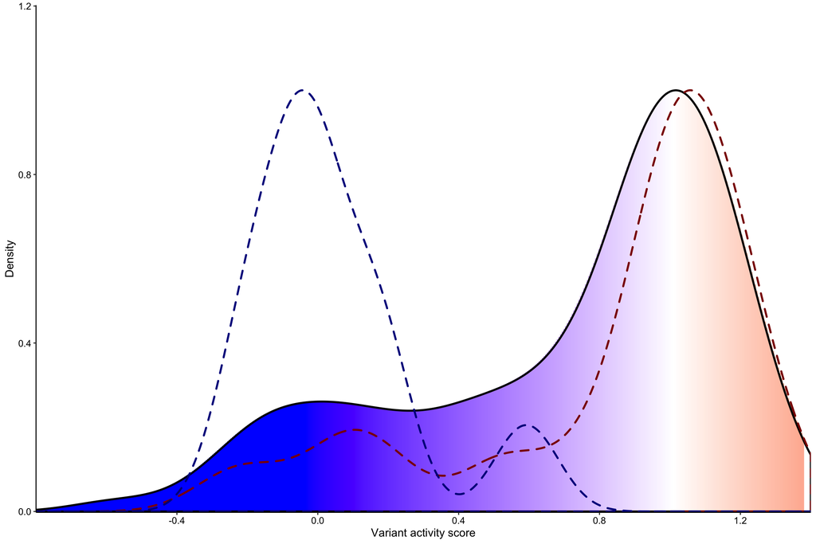

```r
vkor_m <- ggplot(data = subset(vkor_variants, class == "missense"), aes(x = activity_score, y = ..scaled..))
vkor_m <- vkor_m + geom_density()
vkor_q <- ggplot_build(vkor_m)$data[[1]]
vkor_q_low <- subset(vkor_q, x <= vkor_lower_bound_activity)
vkor_q_mid <- subset(vkor_q, x > vkor_lower_bound_activity & x < vkor_upper_bound_activity)
vkor_q_high <- subset(vkor_q, x >= vkor_upper_bound_activity)

vkor_heatmap_density_activity <- ggplot() +
geom_segment(data = vkor_q_low , aes(x = x, y = y, xend = x, yend = 0), colour = "blue", size = 2) +
geom_segment(data = vkor_q_mid, aes(x = x, y = y, xend = x, yend = 0, colour = x), size = 2) +
geom_segment(data = vkor_q_high, aes(x = x, y = y, xend = x, yend = 0, colour = x), size = 2) +
geom_density(data = subset(vkor_variants, class == "missense"), aes(x = activity_score, y = ..scaled..), size = 1) +
scale_color_gradientn(colours = c("blue","white","red"), values = rescale(c(vkor_lower_bound_activity,vkor_upper_bound_activity,2)), limits=c(vkor_lower_bound_activity,2)) +
scale_x_continuous(limits = c(-0.8, 1.4), breaks = seq(-0.4,1.4,0.4), expand = c(0,0)) +
scale_y_continuous(limits = c(0,1.2), breaks = c(0,0.4,0.8,1.2), expand = c(0,0.002)) + xlab("Variant activity score") + ylab("Density") +
  theme(panel.background = element_rect(fill = "white"),
        legend.position = "none",
        panel.grid.minor = element_blank(),
        axis.text.x =element_text(size=10,color="black"),
        axis.text.y=element_text(size=10,color="black"),
        axis.title=element_text(size=12,color="black")) +
geom_density(data = subset(vkor_variants, class == "synonymous"), aes(x = activity_score, y = ..scaled..), color = "darkred", alpha = 0.4, size = 1, linetype = 2) +
geom_density(data = subset(vkor_variants, class == "nonsense" & position < 142), aes(x = activity_score, y = ..scaled..), color = "darkblue", alpha = 0.4, size = 1, linetype = 2)
plot(vkor_heatmap_density_activity)
```

```r
ggsave(file = "Output/vkor_heatmap_density_activity.pdf", vkor_heatmap_density_activity, height = 2.5, width = 4)
```